# COVID‑19 Outcomes Across Economic Groups: A Cross‑Country Data Analysis

2025-06-24

### Part 1: Data wrangling and integration

Loading relevant r packages:

```r
library(tidyverse)
library(here)
```

Firstly we will import each of the three datasets and examine the tables columns and data types.

Importing “Covid.Data” table and viewing the table:

```r
#import Covid dataset
Covid.data <- read.csv(here("Raw Data", "Covid-data.csv"),)

head(Covid.data)
```

```
##    location       date total_cases new_cases total_deaths new_deaths
## 1 Australia 2019-12-31           0         0            0          0
## 2 Australia 2020-01-01           0         0            0          0
## 3 Australia 2020-01-02           0         0            0          0
## 4 Australia 2020-01-03           0         0            0          0
## 5 Australia 2020-01-04           0         0            0          0
## 6 Australia 2020-01-05           0         0            0          0
##   gdp_per_capita population
## 1       44648.71   25499881
## 2       44648.71   25499881
## 3       44648.71   25499881
## 4       44648.71   25499881
## 5       44648.71   25499881
## 6       44648.71   25499881
```

The “Covid.data” table appears to show the amount of new covid cases and deaths classified by date and country while also displaying the countries gdp per capita and total population.

```r
#Selecting rows with missing data
Covid.data_missing <- Covid.data[!complete.cases(Covid.data), ]
Covid.data_missing
```

```
##            location       date total_cases new_cases total_deaths new_deaths
## 101       Australia 2020-04-09        6052        96           50         NA
## 251           China 2020-02-22       76369       826           NA        109
## 301           China 2020-04-12       83097        93         3343         NA
## 501          France 2020-04-15      103573      5497        15729         NA
## 651            Iran 2020-02-28         245       106           NA          7
## 681            Iran 2020-03-29       35408      3076           NA        139
## 701            Iran 2020-04-18       79494      1499         4958         NA
## 851           Italy 2020-03-02        1689       561           NA          6
## 901           Italy 2020-04-21      181228      2256        24114         NA
## 1201 United Kingdom 2020-01-19           0         0           NA         NA
## 1501  United States 2020-05-01     1069826     29917           NA         NA
##      gdp_per_capita population
## 101        44648.71   25499881
## 251        15308.71 1439323774
## 301        15308.71 1439323774
## 501        38605.67   65273512
## 651        19082.62   83992953
## 681        19082.62   83992953
## 701        19082.62   83992953
## 851        35220.08   60461828
## 901        35220.08   60461828
## 1201       39753.24   67886004
## 1501       54225.45  331002647
```

As we can see there are 11 rows with missing data in this table. These NA values take place within the “new_deaths” and “total_deaths” columns. Interestingly they all appear on rows ending in 1, eg 101, 251 etc.

```r
# Start with a clean copy
covid.data_tidy <- Covid.data %>%
  arrange(location, date) %>%   # ensure correct chronological order
  mutate(row_id = row_number())

# Impute missing total_deaths using cumulative logic
# Identify rows where total_deaths is missing
missing_total <- covid.data_tidy %>%
  filter(is.na(total_deaths)) %>%
  pull(row_id)

# Reconstruct total_deaths using previous day's cumulative total
covid.data_tidy <- covid.data_tidy %>%
  mutate(
    total_deaths = if_else(
      is.na(total_deaths),
      lag(total_deaths) + new_deaths,
      total_deaths
    )
  )

# Inspect affected rows
covid.data_tidy %>%
  slice(sort(c(missing_total - 1, missing_total)))
```

```
##          location       date total_cases new_cases total_deaths new_deaths
## 1           China 2020-02-21       75543       891         2238        118
## 2           China 2020-02-22       76369       826         2347        109
## 3            Iran 2020-02-27         139        44           19          4
## 4            Iran 2020-02-28         245       106           26          7
## 5            Iran 2020-03-27       29406      2389         2234        157
## 6            Iran 2020-03-29       35408      3076         2373        139
## 7           Italy 2020-03-01        1128       240           29          8
## 8           Italy 2020-03-02        1689       561           35          6
## 9  United Kingdom 2020-01-18           0         0            0          0
## 10 United Kingdom 2020-01-19           0         0           NA         NA
## 11  United States 2020-04-30     1039909     27326        60966       2611
## 12  United States 2020-05-01     1069826     29917           NA         NA
##    gdp_per_capita population row_id
## 1        15308.71 1439323774    251
## 2        15308.71 1439323774    252
## 3        19082.62   83992953    635
## 4        19082.62   83992953    636
## 5        19082.62   83992953    660
## 6        19082.62   83992953    661
## 7        35220.08   60461828    826
## 8        35220.08   60461828    827
## 9        39753.24   67886004   1187
## 10       39753.24   67886004   1188
## 11       54225.45  331002647   1444
## 12       54225.45  331002647   1445
```

For missing new deaths we can get the total deaths from the next day and subtract them by the total deaths in the row with the missing new deaths to get the missing value.

```r
#calculate missing values for new deaths
# Identify rows where new_deaths is missing
missing_new <- covid.data_tidy %>%
  filter(is.na(new_deaths)) %>%
  pull(row_id)

# Reconstruct new_deaths using difference between cumulative totals
covid.data_tidy <- covid.data_tidy %>%
  mutate(
    new_deaths = if_else(
      is.na(new_deaths),
      total_deaths - lag(total_deaths),
      new_deaths
    )
  )

# Inspect affected rows to check new deaths columns
covid.data_tidy %>%
  slice(sort(c(missing_new - 1, missing_new)))
```

```
##          location       date total_cases new_cases total_deaths new_deaths
## 1       Australia 2020-04-08        5956       112           45          3
## 2       Australia 2020-04-09        6052        96           50          5
## 3           China 2020-04-11       83004        79         3343          3
## 4           China 2020-04-12       83097        93         3343          0
## 5          France 2020-04-14       98076      2673        14967        574
## 6          France 2020-04-15      103573      5497        15729        762
## 7            Iran 2020-04-16       76389      1512         4777         94
## 8            Iran 2020-04-18       79494      1499         4958        181
## 9           Italy 2020-04-20      178972      3047        23660        433
## 10          Italy 2020-04-21      181228      2256        24114        454
## 11 United Kingdom 2020-01-18           0         0            0          0
## 12 United Kingdom 2020-01-19           0         0           NA         NA
## 13  United States 2020-04-30     1039909     27326        60966       2611
## 14  United States 2020-05-01     1069826     29917           NA         NA
##    gdp_per_capita population row_id
## 1        44648.71   25499881    106
## 2        44648.71   25499881    107
## 3        15308.71 1439323774    294
## 4        15308.71 1439323774    295
## 5        38605.67   65273512    490
## 6        38605.67   65273512    491
## 7        19082.62   83992953    678
## 8        19082.62   83992953    679
## 9        35220.08   60461828    871
## 10       35220.08   60461828    872
## 11       39753.24   67886004   1187
## 12       39753.24   67886004   1188
## 13       54225.45  331002647   1444
## 14       54225.45  331002647   1445
```

For UK on 2020-01-19 which has 0 cases and 0 total cases we must update total_deaths and new_deaths by changing their value to 0 since it is impossible to die from covid if you do not have covid.

```r
# Filter row based on location and date and replace new and total deaths values to 0
covid.data_tidy <- covid.data_tidy %>%
  mutate(
    total_deaths = if_else(
      location == "United Kingdom" &
      date == as.Date("2020-01-19") &
      is.na(total_deaths),
      0,
      total_deaths
    ),
    new_deaths = if_else(
      location == "United Kingdom" &
      date == as.Date("2020-01-19") &
      is.na(new_deaths),
      0,
      new_deaths
    )
  )


# Inspect affected rows
covid.data_tidy %>%
  filter(location == "United Kingdom",
         as.Date(date) == as.Date("2020-01-19"))
```

```
##         location       date total_cases new_cases total_deaths new_deaths
## 1 United Kingdom 2020-01-19           0         0            0          0
##   gdp_per_capita population row_id
## 1       39753.24   67886004   1188
```

```r
# --- 1. Calculate missing total_deaths for 2020-05-01 ---

# Values from 2020-05-02
us_total_0502 <- covid.data_tidy %>%
  filter(location == "United States",
         date == as.Date("2020-05-02")) %>%
  pull(total_deaths)

us_new_0502 <- covid.data_tidy %>%
  filter(location == "United States",
         date == as.Date("2020-05-02")) %>%
  pull(new_deaths)

# Update total_deaths for 2020-05-01
covid.data_tidy <- covid.data_tidy %>%
  mutate(
    total_deaths = if_else(
      location == "United States" &
      date == as.Date("2020-05-01") &
      is.na(total_deaths),
      us_total_0502 - us_new_0502,
      total_deaths
    )
  )


# --- 2. Calculate missing new_deaths for 2020-05-01 ---

# Values from 2020-05-01 and 2020-04-30
us_total_0501 <- covid.data_tidy %>%
  filter(location == "United States",
         date == as.Date("2020-05-01")) %>%
  pull(total_deaths)

us_total_0430 <- covid.data_tidy %>%
  filter(location == "United States",
         date == as.Date("2020-04-30")) %>%
  pull(total_deaths)

# Update new_deaths for 2020-05-01
covid.data_tidy <- covid.data_tidy %>%
  mutate(
    new_deaths = if_else(
      location == "United States" &
      date == as.Date("2020-05-01") &
      is.na(new_deaths),
      us_total_0501 - us_total_0430,
      new_deaths
    )
  )

#view column to check updated values
covid.data_tidy %>%
  filter(location == "United States",
         date == as.Date("2020-05-01"))
```

```
##        location       date total_cases new_cases total_deaths new_deaths
## 1 United States 2020-05-01     1069826     29917        63006       2040
##   gdp_per_capita population row_id
## 1       54225.45  331002647   1445
```

Now we will check the covid.data_tidy table again to see if all the missing values have been filled.

```r
#Check for missing values
covid.data_tidy[!complete.cases(covid.data_tidy), ]
```

```
## [1] location       date           total_cases    new_cases      total_deaths
## [6] new_deaths     gdp_per_capita population     row_id
## <0 rows> (or 0-length row.names)
```

And if all the code chunks have been executed in sequential order we can see there are no more missing values for the covid.data table.

Now we will import data from the countrylockdowndates table

```r
CountryLockdowndates <- read.csv(here("Raw Data", "CountryLockdowndates.csv"))
head(CountryLockdowndates, 10)
```

```
##         Country.Region                     Province       Date Type
## 1          Afghanistan                              24/03/2020 Full
## 2              Albania                              08/03/2020 Full
## 3              Algeria                              24/03/2020 Full
## 4              Andorra                              16/03/2020 Full
## 5               Angola                              24/03/2020 Full
## 6  Antigua and Barbuda                                         None
## 7            Argentina                              20/03/2020 Full
## 8              Armenia                              24/03/2020 Full
## 9            Australia Australian Capital Territory            None
## 10           Australia              New South Wales            None
##                                                                                                                                     Reference
## 1                               https://www.thestatesman.com/world/afghan-govt-imposes-lockdown-coronavirus-cases-increase-15-1502870945.html
## 2                                                                          https://en.wikipedia.org/wiki/2020_coronavirus_pandemic_in_Albania
## 3  https://www.garda.com/crisis24/news-alerts/325896/algeria-government-implements-lockdown-and-curfew-in-blida-and-algiers-march-23-update-7
## 4                                                                          https://en.wikipedia.org/wiki/2020_coronavirus_pandemic_in_Andorra
## 5                                                                           https://en.wikipedia.org/wiki/2020_coronavirus_pandemic_in_Angola
## 6
## 7                            https://www.bloomberg.com/news/articles/2020-03-20/argentina-orders-exceptional-lockdown-in-bid-to-contain-virus
## 8                                                                                                    https://www.azatutyun.am/a/30506939.html
## 9                                                                        https://en.wikipedia.org/wiki/2020_coronavirus_pandemic_in_Australia
## 10                                                                       https://en.wikipedia.org/wiki/2020_coronavirus_pandemic_in_Australia
```

This table shows a list of countries, the type of lockdown they had during covid and when they went on lockdown.

selecting rows with missing data:

```r
#Select rows with missing data
CountryLockdowndates_missing <- CountryLockdowndates[!complete.cases(CountryLockdowndates), ]
CountryLockdowndates_missing
```

```
## [1] Country.Region Province       Date           Type           Reference
## <0 rows> (or 0-length row.names)
```

This shows that the table country lockdown dates has no missing values.

Finally we will now import the final data set worldwidevaccinedata

```r
#Import worldwide vaccine data table
WorldwideVaccineData <- read.csv(here("Raw Data", "WorldwideVaccineData.csv"), header=TRUE)
head(WorldwideVaccineData)
```

```
##       Country Doses.administered.per.100.people Total.doses.administered
## 1 Afghanistan                                17                  6445359
## 2     Albania                               102                  2906126
## 3     Algeria                                35                 15205854
## 4      Angola                                64                 20397115
## 5   Argentina                               237                106474858
## 6     Armenia                                73                  2150112
##   X..of.population.vaccinated X..of.population.fully.vaccinated
## 1                          15                                13
## 2                          46                                44
## 3                          19                                16
## 4                          41                                22
## 5                          92                                84
## 6                          38                                33
```

This table shows a list of countries statistics relating to the proportion of their population who have been fully and partially vaccinated against covid.

selecting rows with missing data:

```r
#Select missing data
vaccine_missing <- WorldwideVaccineData[!complete.cases(WorldwideVaccineData), ]
vaccine_missing
```

```
## [1] Country                           Doses.administered.per.100.people
## [3] Total.doses.administered          X..of.population.vaccinated
## [5] X..of.population.fully.vaccinated
## <0 rows> (or 0-length row.names)
```

Since 0 rows are selected this missing there is no missing data in this table.

Before we can join these three data sets into one table we need to convert the different date columns into the formats.

At the moment the CountryLockdowndates table has dates in the format dd/mm/yyyy, while the covid.data_tidy table has dates in the format yyyy-mm-dd. To make things consistent we will convert the date format int eh CountryLockdowndates table to the universal date format of yyyy-mm-dd.

```r
#Converting CountryLockdowndates dates column to yyyy-mm-dd

for (index in seq_along(CountryLockdowndates[,3])){
  date <- CountryLockdowndates[index ,3]
  if (date != ""){
    input_date <- as.Date(date, format = "%d/%m/%Y")
    CountryLockdowndates[index, 3] <- format(input_date, "%Y-%m-%d")
  }
}
head(CountryLockdowndates, 10)
```

```
##         Country.Region                     Province       Date Type
## 1          Afghanistan                              2020-03-24 Full
## 2              Albania                              2020-03-08 Full
## 3              Algeria                              2020-03-24 Full
## 4              Andorra                              2020-03-16 Full
## 5               Angola                              2020-03-24 Full
## 6  Antigua and Barbuda                                         None
## 7            Argentina                              2020-03-20 Full
## 8              Armenia                              2020-03-24 Full
## 9            Australia Australian Capital Territory            None
## 10           Australia              New South Wales            None
##                                                                                                                                     Reference
## 1                               https://www.thestatesman.com/world/afghan-govt-imposes-lockdown-coronavirus-cases-increase-15-1502870945.html
## 2                                                                          https://en.wikipedia.org/wiki/2020_coronavirus_pandemic_in_Albania
## 3  https://www.garda.com/crisis24/news-alerts/325896/algeria-government-implements-lockdown-and-curfew-in-blida-and-algiers-march-23-update-7
## 4                                                                          https://en.wikipedia.org/wiki/2020_coronavirus_pandemic_in_Andorra
## 5                                                                           https://en.wikipedia.org/wiki/2020_coronavirus_pandemic_in_Angola
## 6
## 7                            https://www.bloomberg.com/news/articles/2020-03-20/argentina-orders-exceptional-lockdown-in-bid-to-contain-virus
## 8                                                                                                    https://www.azatutyun.am/a/30506939.html
## 9                                                                        https://en.wikipedia.org/wiki/2020_coronavirus_pandemic_in_Australia
## 10                                                                       https://en.wikipedia.org/wiki/2020_coronavirus_pandemic_in_Australia
```

Now we will rename the country.region column name so we can join it with the location column in the covid.data_tidy table.

```r
#renaming CountryLockdowndates columns country.region to location and date to lockdown date
names(CountryLockdowndates)[names(CountryLockdowndates) == "Country.Region"] <- "location"
names(CountryLockdowndates)[names(CountryLockdowndates) == "Date"] <- "lockdown_date"
```

Now we will remove columns from the countrylockdowndates table that we do not want to use and display all of the locations that are in duplicate.

```r
# add new data frame to manipulate
lock_down <- CountryLockdowndates
#select all countries with duplicates
lock_down <- lock_down %>%
  arrange(location, lockdown_date) %>%
  filter(duplicated(location)== TRUE)
#select to only display location and lockdown_date
lock_down <- subset(lock_down, select = c(location, lockdown_date))
#Display first 10 rows
head(lock_down,10)
```

```
##     location lockdown_date
## 1  Australia
## 2  Australia
## 3  Australia
## 4  Australia
## 5  Australia
## 6  Australia
## 7  Australia    2020-03-24
## 8     Canada    2020-03-14
## 9     Canada    2020-03-16
## 10    Canada    2020-03-17
```

As we can see Australia, Canada, China, France, Netherlands, US, United Kingdom have multiple dates for lockdown_date, this is due to the different regions/ states within the countries having their own dates for lockdowns. To tidy our data in the lock_down table we will only have 1 row for each country and the lockdown date will be the earliest within that countries provences.

```r
#add new data frame to manipulate
lock_down <- CountryLockdowndates
#Remove duplicate countries
lock_down <- lock_down %>%
  arrange(location, lockdown_date) %>%
  filter(duplicated(location)== FALSE)
#select to only display location and lockdown_date
lock_down <- subset(lock_down, select = c(location, lockdown_date))
#Assign earliest lockdown dates to duplicate countries
lock_down[9,2] <- "2020-03-24" #Australia
lock_down[32,2] <- "2020-03-14" #Canada
lock_down[36,2] <- "2020-01-23" #China
lock_down[61,2] <- "2020-03-16" #France
lock_down[120,2] <- "2020-03-16" #Netherlands
lock_down[170,2] <- "2020-03-13" #US
lock_down[174,2] <- "2020-03-18" #United Kingdom
```

Now We will rename the country column in worldwidevaccinedata to location too.

```r
#renaming worldwidevaccinedata country column to location
names(WorldwideVaccineData)[names(WorldwideVaccineData) == "Country"] <- "location"
```

Now that the dates in both tables have the same format now we can join the three tables. To do this we will perform multiple inner joins joining on the location.

```r
#inner join covid.data_tidy to worldwidevaccinedata on location column
covid_data_vaccine_join <- inner_join(covid.data_tidy, WorldwideVaccineData, by = "location")
head(covid_data_vaccine_join)
```

```
##    location       date total_cases new_cases total_deaths new_deaths
## 1 Australia 2019-12-31           0         0            0          0
## 2 Australia 2020-01-01           0         0            0          0
## 3 Australia 2020-01-02           0         0            0          0
## 4 Australia 2020-01-03           0         0            0          0
## 5 Australia 2020-01-04           0         0            0          0
## 6 Australia 2020-01-05           0         0            0          0
##   gdp_per_capita population row_id Doses.administered.per.100.people
## 1       44648.71   25499881      9                               229
## 2       44648.71   25499881     10                               229
## 3       44648.71   25499881     11                               229
## 4       44648.71   25499881     12                               229
## 5       44648.71   25499881     13                               229
## 6       44648.71   25499881     14                               229
##   Total.doses.administered X..of.population.vaccinated
## 1                 57988175                          88
## 2                 57988175                          88
## 3                 57988175                          88
## 4                 57988175                          88
## 5                 57988175                          88
## 6                 57988175                          88
##   X..of.population.fully.vaccinated
## 1                                86
## 2                                86
## 3                                86
## 4                                86
## 5                                86
## 6                                86
```

Now we will inner join our covid_data_vaccine_join table to countrylockdowndates table.

```r
#Joining covide_data_vaccine_join with countrylockdowndates
covid_data_joined <- inner_join(covid_data_vaccine_join, lock_down, by = "location")

head(covid_data_joined)
```

```
##    location       date total_cases new_cases total_deaths new_deaths
## 1 Australia 2019-12-31           0         0            0          0
## 2 Australia 2020-01-01           0         0            0          0
## 3 Australia 2020-01-02           0         0            0          0
## 4 Australia 2020-01-03           0         0            0          0
## 5 Australia 2020-01-04           0         0            0          0
## 6 Australia 2020-01-05           0         0            0          0
##   gdp_per_capita population row_id Doses.administered.per.100.people
## 1       44648.71   25499881      9                               229
## 2       44648.71   25499881     10                               229
## 3       44648.71   25499881     11                               229
## 4       44648.71   25499881     12                               229
## 5       44648.71   25499881     13                               229
## 6       44648.71   25499881     14                               229
##   Total.doses.administered X..of.population.vaccinated
## 1                 57988175                          88
## 2                 57988175                          88
## 3                 57988175                          88
## 4                 57988175                          88
## 5                 57988175                          88
## 6                 57988175                          88
##   X..of.population.fully.vaccinated lockdown_date
## 1                                86    2020-03-24
## 2                                86    2020-03-24
## 3                                86    2020-03-24
## 4                                86    2020-03-24
## 5                                86    2020-03-24
## 6                                86    2020-03-24
```

Now that all the tables have been joined we can now remove the columns we are not interested in.

```r
#remove columns that are not needed
covid_data_joined <- subset(covid_data_joined, select = -c(Doses.administered.per.100.people, X..of.population.vaccinated, row_id))
#rename columns
names(covid_data_joined)[names(covid_data_joined) == "Total.doses.administered"] <- "total_doses_administered"
names(covid_data_joined)[names(covid_data_joined) == "X..of.population.vaccinated"] <- "%_of_population_fully_vaccinated"
head(covid_data_joined)
```

```
##    location       date total_cases new_cases total_deaths new_deaths
## 1 Australia 2019-12-31           0         0            0          0
## 2 Australia 2020-01-01           0         0            0          0
## 3 Australia 2020-01-02           0         0            0          0
## 4 Australia 2020-01-03           0         0            0          0
## 5 Australia 2020-01-04           0         0            0          0
## 6 Australia 2020-01-05           0         0            0          0
##   gdp_per_capita population total_doses_administered
## 1       44648.71   25499881                 57988175
## 2       44648.71   25499881                 57988175
## 3       44648.71   25499881                 57988175
## 4       44648.71   25499881                 57988175
## 5       44648.71   25499881                 57988175
## 6       44648.71   25499881                 57988175
##   X..of.population.fully.vaccinated lockdown_date
## 1                                86    2020-03-24
## 2                                86    2020-03-24
## 3                                86    2020-03-24
## 4                                86    2020-03-24
## 5                                86    2020-03-24
## 6                                86    2020-03-24
```

Now we will convert our date and lockdown_date columns to date format.

```r
#Convert date column from chr data type to date data type
covid_data_joined <- mutate(covid_data_joined, date = as.Date(date, format = "%Y-%m-%d"))
#Convert lockdown_date column from chr data type to date data type
covid_data_joined <- mutate(covid_data_joined, lockdown_date = as.Date(lockdown_date, format = "%Y-%m-%d"))
#check for errors or missing values
covid_data_joined_missing <- covid_data_joined[!complete.cases(covid_data_joined), ]
head(covid_data_joined_missing)
```

```
##      location date total_cases new_cases total_deaths new_deaths gdp_per_capita
## 188 Australia <NA>        7335        15          102          0       44648.71
## 189 Australia <NA>        7370        23          102          0       44648.71
## 190 Australia <NA>        7492        18          102          0       44648.71
## 367    France <NA>      140227       708        26991        348       38605.67
## 368    France <NA>      157372       152        29436         29       38605.67
## 369    France <NA>          12         1            1          0       38605.67
##     population total_doses_administered X..of.population.fully.vaccinated
## 188   25499881                 57988175                                86
## 189   25499881                 57988175                                86
## 190   25499881                 57988175                                86
## 367   65273512                146731437                                79
## 368   65273512                146731437                                79
## 369   65273512                146731437                                79
##     lockdown_date
## 188    2020-03-24
## 189    2020-03-24
## 190    2020-03-24
## 367    2020-03-16
## 368    2020-03-16
## 369    2020-03-16
```

It appears that some date columns are in the incorrect format and will need to be changed to the correct format.

```r
#Assigning loop output to a new variable
date_correct_loop <- covid_data_joined
#For loop to search date column to find na and replace it with date from previous index +1 day
for(index in seq_along(date_correct_loop[,2])){
  if(is.na(date_correct_loop[index,2])){
    date_correct_loop[index,2] <- date_correct_loop[index-1,2]+1
  }
}
#Check for missing values
date_correct_loop[!complete.cases(date_correct_loop), ]
```

```
##  [1] location                          date
##  [3] total_cases                       new_cases
##  [5] total_deaths                      new_deaths
##  [7] gdp_per_capita                    population
##  [9] total_doses_administered          X..of.population.fully.vaccinated
## [11] lockdown_date
## <0 rows> (or 0-length row.names)
```

Now we can check if the dates have been correctly assigned.

```r
#Check previous missing indexes for correct date changes
date_correct_loop[c(162, 163, 164, 165, 166, 213, 214, 215), ]
```

```
##      location       date total_cases new_cases total_deaths new_deaths
## 162 Australia 2020-06-15        7320        18          102          0
## 163 Australia 2020-06-17        7347        12          102          0
## 164 Australia 2020-06-19        7391        21          102          0
## 165 Australia 2020-06-20        7409        18          102          0
## 166 Australia 2020-06-21        7436        27          102          0
## 213    France 2020-01-22           0         0            0          0
## 214    France 2020-01-24           0         0            0          0
## 215    France 2020-01-25           3         3            0          0
##     gdp_per_capita population total_doses_administered
## 162       44648.71   25499881                 57988175
## 163       44648.71   25499881                 57988175
## 164       44648.71   25499881                 57988175
## 165       44648.71   25499881                 57988175
## 166       44648.71   25499881                 57988175
## 213       38605.67   65273512                146731437
## 214       38605.67   65273512                146731437
## 215       38605.67   65273512                146731437
##     X..of.population.fully.vaccinated lockdown_date
## 162                                86    2020-03-24
## 163                                86    2020-03-24
## 164                                86    2020-03-24
## 165                                86    2020-03-24
## 166                                86    2020-03-24
## 213                                79    2020-03-16
## 214                                79    2020-03-16
## 215                                79    2020-03-16
```

```r
#Examine case/ death columns for negative values
if (count(filter(date_correct_loop, total_cases < 0)) >0){
  print("Negative values in: total_cases")
}
if (count(filter(date_correct_loop, new_cases < 0)) >0){
  print("Negative values in: new_cases")
}
```

```
## [1] "Negative values in: new_cases"
```

```r
if (count(filter(date_correct_loop, total_deaths < 0)) >0){
  print("Negative values in: total_deaths")
}
if (count(filter(date_correct_loop, new_deaths < 0)) >0){
  print("Negative values in: new_deaths")
}
```

```
## [1] "Negative values in: new_deaths"
```

Since we have negative values in our new_cases and new_deaths columns we will need to find them and correct them.

```r
#Select rows with negative data
negative_values <- filter(date_correct_loop, new_deaths <0 | new_cases <0)
negative_values
```

```
##   location       date total_cases new_cases total_deaths new_deaths
## 1   France 2020-06-03      151325      -766        28940        107
## 2    Italy 2020-06-25      239410       577        34644        -31
## 3    Spain 2020-04-19      193252      -713        20453        410
## 4    Spain 2020-05-25      235400      -372        26834      -1918
##   gdp_per_capita population total_doses_administered
## 1       38605.67   65273512                146731437
## 2       35220.08   60461828                138427859
## 3       34272.36   46754783                 95245599
## 4       34272.36   46754783                 95245599
##   X..of.population.fully.vaccinated lockdown_date
## 1                                79    2020-03-16
## 2                                80    2020-03-11
## 3                                86    2020-03-14
## 4                                86    2020-03-14
```

```r
#Examine dates before the rows with negative values to check if negative values can be multiplied by -1
filter(date_correct_loop, date == "2020-06-05" & location == "France")
```

```
##   location       date total_cases new_cases total_deaths new_deaths
## 1   France 2020-06-05      152444       767        29065         44
##   gdp_per_capita population total_doses_administered
## 1       38605.67   65273512                146731437
##   X..of.population.fully.vaccinated lockdown_date
## 1                                79    2020-03-16
```

```r
filter(date_correct_loop, date == "2020-06-24" & location == "Italy")
```

```
##  [1] location                          date
##  [3] total_cases                       new_cases
##  [5] total_deaths                      new_deaths
##  [7] gdp_per_capita                    population
##  [9] total_doses_administered          X..of.population.fully.vaccinated
## [11] lockdown_date
## <0 rows> (or 0-length row.names)
```

```r
filter(date_correct_loop, date == "2020-04-18" & location == "Spain")
```

```
##  [1] location                          date
##  [3] total_cases                       new_cases
##  [5] total_deaths                      new_deaths
##  [7] gdp_per_capita                    population
##  [9] total_doses_administered          X..of.population.fully.vaccinated
## [11] lockdown_date
## <0 rows> (or 0-length row.names)
```

```r
filter(date_correct_loop, date == "2020-05-24" & location == "Spain")
```

```
##   location       date total_cases new_cases total_deaths new_deaths
## 1    Spain 2020-05-24      235772       482        28752         74
##   gdp_per_capita population total_doses_administered
## 1       34272.36   46754783                 95245599
##   X..of.population.fully.vaccinated lockdown_date
## 1                                86    2020-03-14
```

As we can see here with the different extracted data frames the rows with negative values have affected the corresponding total column as well so we will need t o multiple the negative value by -1 and add the new value to the total column to fix it.

```r
#Assign loop variable for negative values loop
negative_val_loop <- date_correct_loop
#For loop to search for rows with negative values in new_cases, multiply the value be -1 and add the value to correct the corresponding total column
for(i in seq_along(negative_val_loop[,4])){
 if (negative_val_loop[i,4] < 0){
   negative_val_loop[i,4] <- negative_val_loop[i,4] * -1
   negative_val_loop[i,3] <- negative_val_loop[i,3] + negative_val_loop[i,4]

 }
}
#Check for negative values in new_cases
filter(negative_val_loop, new_cases < 0)
```

```
##  [1] location                          date
##  [3] total_cases                       new_cases
##  [5] total_deaths                      new_deaths
##  [7] gdp_per_capita                    population
##  [9] total_doses_administered          X..of.population.fully.vaccinated
## [11] lockdown_date
## <0 rows> (or 0-length row.names)
```

Now we will perform the same action to the negative values in the new_deaths column.

```r
#For loop to search for rows with negative values in new_deaths, multiply the value be -1 and add the value to correct the corresponding total column
for(i in seq_along(negative_val_loop[,6])){
 if (negative_val_loop[i,6] < 0){
   negative_val_loop[i,6] <- negative_val_loop[i,6] * -1
   negative_val_loop[i,5] <- negative_val_loop[i,5] + negative_val_loop[i,6]

 }
}
#Check for negative values in new_deaths
filter(negative_val_loop, new_cases < 0)
```

```
##  [1] location                          date
##  [3] total_cases                       new_cases
##  [5] total_deaths                      new_deaths
##  [7] gdp_per_capita                    population
##  [9] total_doses_administered          X..of.population.fully.vaccinated
## [11] lockdown_date
## <0 rows> (or 0-length row.names)
```

Now we will recalculate the total_cases column using the new_case column to ensure no counting errors have taken place in the table.

```r
# Initialize first row of dataset
negative_val_loop[1, 3] <- negative_val_loop[1, 4]

prev_country <- negative_val_loop[1, 1]
prev_date    <- negative_val_loop[1, 2]

for (i in 2:nrow(negative_val_loop)) {

  current_country <- negative_val_loop[i, 1]
  current_date    <- negative_val_loop[i, 2]

  # Case 1: new country → reset cumulative
  if (current_country != prev_country) {
    negative_val_loop[i, 3] <- negative_val_loop[i, 4]
  # Case 2: same country and first non-zero total_cases → convert total_cases to new_cases
  } else if (negative_val_loop[i-1,3] == 0 &&
             negative_val_loop[i-1,4] == 0) {
    negative_val_loop[i,3] <- negative_val_loop[i,4]
  # Case 3: same country AND consecutive date → cumulative update
  } else if (current_date == prev_date + 1) {
    negative_val_loop[i, 3] <- negative_val_loop[i - 1, 3] + negative_val_loop[i, 4]

  # Case 4: same country BUT date skipped → keep existing total_cases unless new_cases > total_cases - previous total_cases then add new_cases and previous total_cases together
  } else { if (negative_val_loop[i,3] < negative_val_loop[i-1,3] +
               negative_val_loop[i,4]){
    negative_val_loop[i,3] <- negative_val_loop[i,4] + negative_val_loop[i-1,3]
  }

  }

  # update trackers
  prev_country <- current_country
  prev_date    <- current_date
}
```

Now the the total_cases column is incrementing correctly we will now correct the values in the total_deaths column.

```r
# Initialize first row of dataset
negative_val_loop[1, 5] <- negative_val_loop[1, 6]

prev_country <- negative_val_loop[1, 1]
prev_date    <- negative_val_loop[1, 2]

for (i in 2:nrow(negative_val_loop)) {

  current_country <- negative_val_loop[i, 1]
  current_date    <- negative_val_loop[i, 2]

  # Case 1: new country → reset cumulative
  if (current_country != prev_country) {
    negative_val_loop[i, 5] <- negative_val_loop[i, 6]
  # Case 2: same country and first non-zero total_deaths → convert total_deaths to new_deaths
  } else if (negative_val_loop[i-1,5] == 0 &&
             negative_val_loop[i-1,6] == 0) {
    negative_val_loop[i,5] <- negative_val_loop[i,6]
  # Case 3: same country AND consecutive date → cumulative update
  } else if (current_date == prev_date + 1) {
    negative_val_loop[i, 5] <- negative_val_loop[i - 1, 5] + negative_val_loop[i, 6]

  # Case 4: same country BUT date skipped → keep existing total_deaths unless new_deaths > total_cases - previous total_deaths then add new_deaths and previous total_deaths together
  } else { if (negative_val_loop[i,5] < negative_val_loop[i-1,5] +
               negative_val_loop[i,6]){
    negative_val_loop[i,5] <- negative_val_loop[i,6] + negative_val_loop[i-1,5]
  }

  }

  # update trackers
  prev_country <- current_country
  prev_date    <- current_date
}
```

Lets check our data again for any negative values.

```r
#Examine case/ death columns for negative values
filter(negative_val_loop, total_cases < 0 |
         total_deaths < 0 |
         new_cases < 0 |
         new_deaths <0
       )
```

```
##  [1] location                          date
##  [3] total_cases                       new_cases
##  [5] total_deaths                      new_deaths
##  [7] gdp_per_capita                    population
##  [9] total_doses_administered          X..of.population.fully.vaccinated
## [11] lockdown_date
## <0 rows> (or 0-length row.names)
```

Lets produce a quick plot as a final check to see if there are any irregularties in our data.

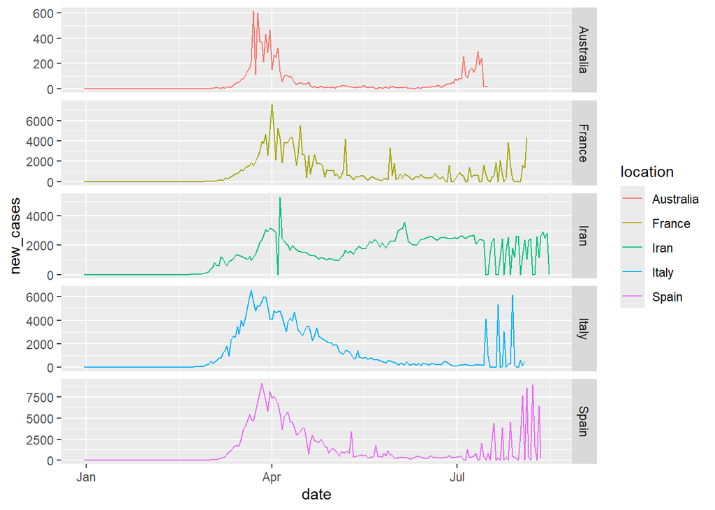

```r
#Plot a line graph using the clean covid data examining new cases over time
ggplot(data = negative_val_loop, aes(x = date, y = new_cases, group = location, color = location))+
  geom_line(linewidth = 0.5)+
  #Split plot by country, give each plot its own scale
  facet_grid(rows = vars(location), scales = "free")
```

As shown in the plot, there is a value in the Iran data that appears inconsistent: new cases drop from several thousand to zero and then return to several thousand the very next day. This pattern is unlikely to reflect real transmission dynamics, so it warrants closer examination to determine whether it represents a reporting delay, a data entry error, or missing information.

```r
#filter data by rows with 0 new_cases and new_deaths when total cases are above 100.
negative_val_loop %>%
filter( new_cases == 0 & new_deaths == 0 & total_cases > 100)
```

```
##    location       date total_cases new_cases total_deaths new_deaths
## 1    France 2020-06-28      163217         0        29778          0
## 2    France 2020-06-29      163217         0        29778          0
## 3    France 2020-07-05      166960         0        29893          0
## 4    France 2020-07-06      166960         0        29893          0
## 5    France 2020-07-12      170752         0        30004          0
## 6    France 2020-07-13      170752         0        30004          0
## 7    France 2020-07-21      176049         0        30748          0
## 8    France 2020-07-24      178741         0        31311          0
## 9    France 2020-07-29      184875         0        32130          0
## 10   France 2020-07-30      184875         0        32130          0
## 11     Iran 2020-04-04       50468         0         3016          0
## 12     Iran 2020-07-15      259652         0        13032          0
## 13     Iran 2020-07-16      259652         0        13032          0
## 14     Iran 2020-07-20      265791         0        13381          0
```

[output cut: 108 more lines]

From the plot above, we can see that there are 40 dates across four countries where both new cases and new deaths are recorded as zero, despite surrounding days showing thousands of cases. This pattern is highly unlikely to reflect real epidemiological conditions and instead suggests missing or incomplete reporting. There are a couple of reasonable approaches to address this anomaly. One option is to verify the correct figures using official government or public‑health sources. Alternatively, we could omit these rows from the dataset; given the size of the full dataset, removing a small number of clearly inaccurate entries is unlikely to materially affect the overall analysis.

```r
#Delete outlier data rows
negative_val_loop_outliers_removed <- negative_val_loop %>%
  filter(!(new_cases == 0 & new_deaths == 0 & total_cases > 100))
```

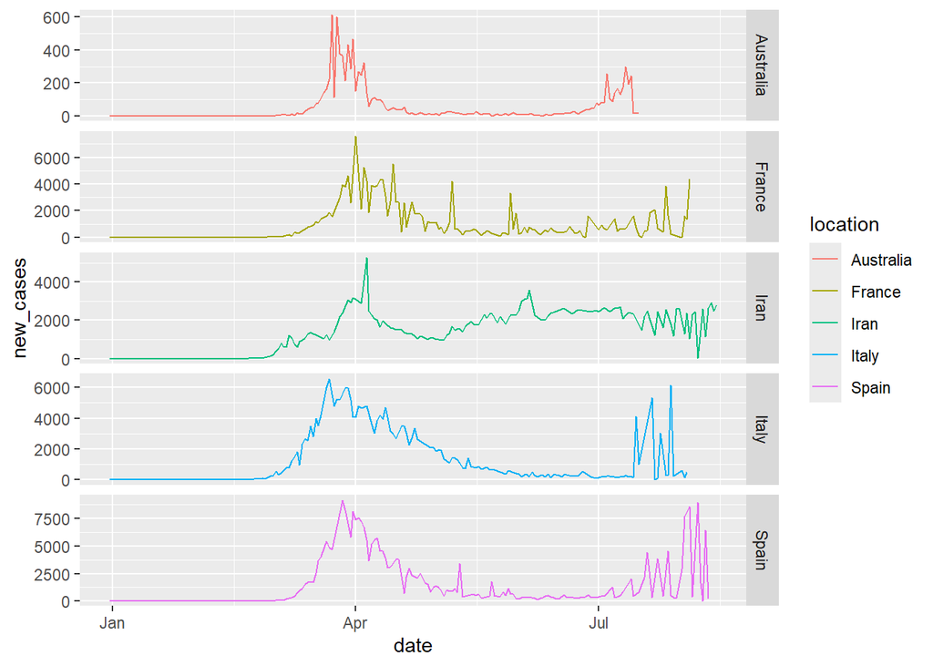

```r
#Plot a line graph using the clean covid data examining new cases over time
ggplot(data = negative_val_loop_outliers_removed, aes(x = date, y = new_cases, group = location, color = location))+
  geom_line(linewidth = 0.5)+
  #Split plot by country, give each plot its own scale
  facet_grid(rows = vars(location), scales = "free")
```

Now we can assign our clean data to a new variable name.

```r
#Reassign cleaned data to a new variable
covid_data_clean <- negative_val_loop_outliers_removed
```

Finally we have our cleaned and joined dataset ready for analysis.

### Part 2: Data visualisation and analysis

First we will create a plot to examine the trend of new cases in each country.

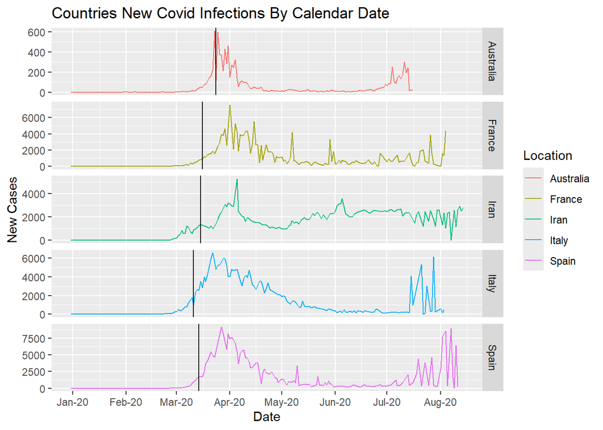

```r
#Plot a line graph using the clean covid data examining new cases over time
ggplot(data = covid_data_clean, aes(x = date, y = new_cases, group = location, color = location))+
  geom_line(linewidth = 0.5)+
  #Scale x-axis by month
  scale_x_date(date_breaks = "1 month", date_labels = "%b-%y")+
  #Split plot by country, give each plot its own scale
  facet_grid(rows = vars(location), scales = "free")+
  #Add title
  labs(title = "Countries New Covid Infections By Calendar Date", colour = "Location")+
  #Add vertical lines representing when lockdowns first began in each of the countries
  geom_vline(data = filter(covid_data_clean, location == "Australia"),
aes(xintercept = covid_data_clean[1,11]))+
  geom_vline(data = filter(covid_data_clean, location == "France"), aes(xintercept = covid_data_clean[213,11]))+
  geom_vline(data = filter(covid_data_clean, location == "Iran"), aes(xintercept = covid_data_clean[400,11]))+
  geom_vline(data = filter(covid_data_clean, location == "Italy"), aes(xintercept = covid_data_clean[588,11]))+
  geom_vline(data = filter(covid_data_clean, location == "Spain"), aes(xintercept = covid_data_clean[808,11]))+
  #Add x-axis label
  xlab("Date")+
  #Add y-axis label
  ylab("New Cases")
```

When examining the plot above, we can see that each country experiences a clear peak in new daily cases around late March to early April, followed by a gradual decline. The black vertical line marks the date each country implemented its first lockdown. For most countries, case numbers begin to fall within roughly a month of these initial restrictions, although the rate of decline varies. Some countries show a sharp and immediate drop, while others display a more gradual reduction, reflecting differences in timing, enforcement, and public adherence to the measures.

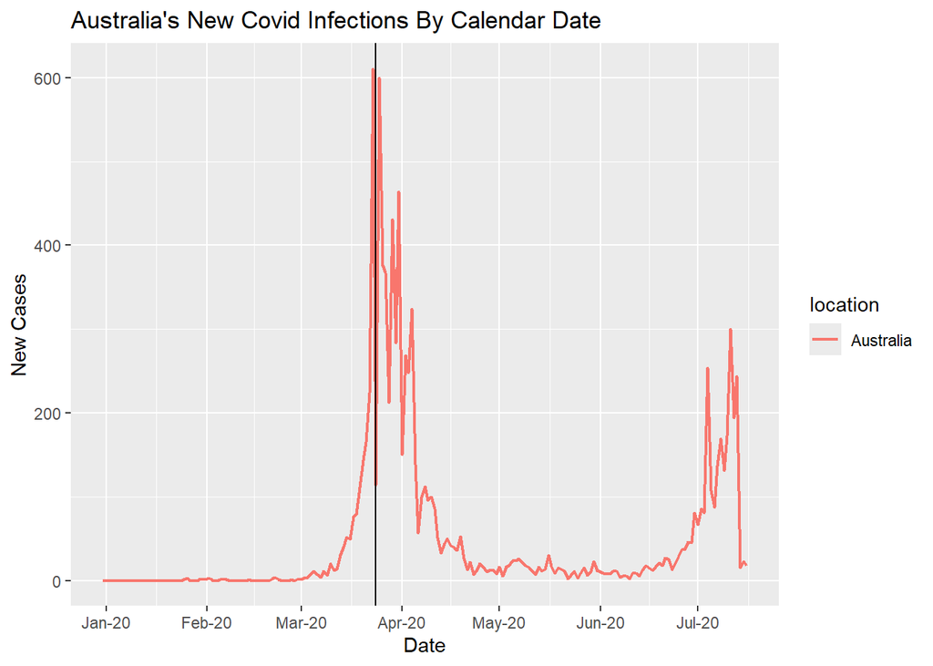

```r
#Plot a line graph using the clean covid data examining new cases over time
ggplot(data = filter(covid_data_clean, location == "Australia"), aes(x = date, y = new_cases, group = location, color = location))+
  geom_line(linewidth = 0.75)+
  #Scale x-axis by month
  scale_x_date(date_breaks = "1 month", date_labels = "%b-%y")+
  #Add title
  labs(title = "Australia's New Covid Infections By Calendar Date")+
  #Add vertical lines representing when lockdowns first began in each of the countries
  geom_vline(data = filter(covid_data_clean, location == "Australia"), aes(xintercept = covid_data_clean[1,11]))+
   #Add x-axis label
  xlab("Date")+
  #Add y-axis label
  ylab("New Cases")
```

In Australia, the data shows a sharp increase in cases during mid‑ to late‑March. On March 20, Australia closed its international borders and introduced social‑distancing laws as part of a zero‑COVID suppression strategy, followed shortly after by the rollout of lockdown measures on March 24. Following these interventions, daily case numbers declined rapidly, falling to almost zero throughout April and May. A renewed spike emerged in July, driven by an outbreak linked to Victoria’s hotel quarantine system, which marked the beginning of the country’s second wave.

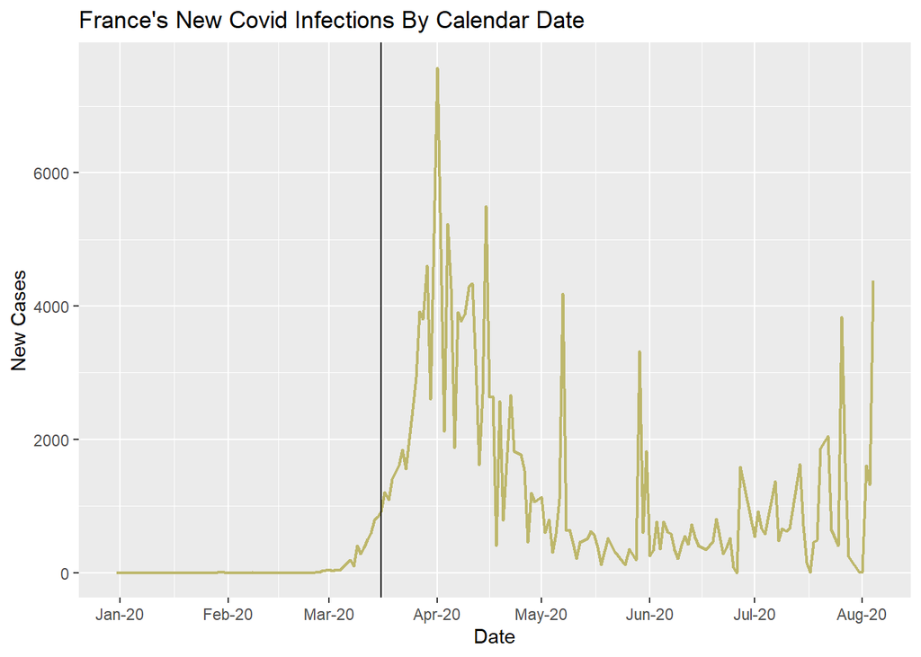

```r
#Plot a line graph using the clean covid data examining new cases over time
ggplot(data = filter(covid_data_clean, location == "France"), aes(x = date, y = new_cases, group = location, color = location))+
  geom_line(linewidth = 0.75, colour = "darkkhaki")+
  #Scale x-axis by month
  scale_x_date(date_breaks = "1 month", date_labels = "%b-%y")+
  #Add title
  labs(title = "France's New Covid Infections By Calendar Date")+
  #Add vertical lines representing when lockdowns first began in each of the countries
  geom_vline(data = filter(covid_data_clean, location == "France"), aes(xintercept = covid_data_clean[213,11]))+
   #Add x-axis label
  xlab("Date")+
  #Add y-axis label
  ylab("New Cases")
```

In France, the data shows a spike in cases similar to Australia’s trend, although the scale is significantly larger, with case numbers reaching roughly ten times higher. France implemented its lockdown measures over several days, and because daily cases were already elevated at the time restrictions began, there was a noticeable lag before case numbers started to decline. The spike observed in mid‑May likely reflects the easing of restrictions, including the reopening of schools, which increased opportunities for transmission.

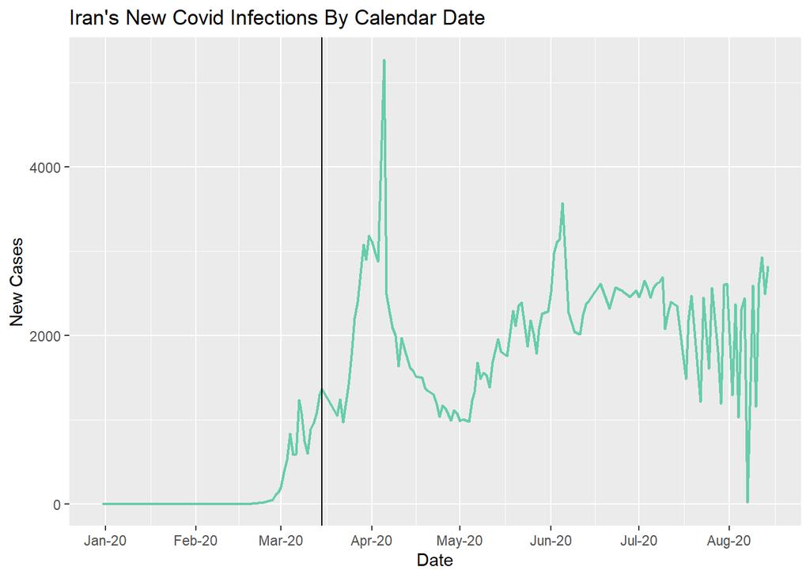

```r
#Plot a line graph using the clean covid data examining new cases over time
ggplot(data = filter(covid_data_clean, location == "Iran"), aes(x = date, y = new_cases, group = location, color = location))+
  geom_line(linewidth = 0.75, colour = "aquamarine3")+
  #Scale x-axis by month
  scale_x_date(date_breaks = "1 month", date_labels = "%b-%y")+
  #Add title
  labs(title = "Iran's New Covid Infections By Calendar Date")+
  #Add vertical lines representing when lockdowns first began in each of the countries
  geom_vline(data = filter(covid_data_clean, location == "Iran"), aes(xintercept = covid_data_clean[400,11]))+
   #Add x-axis label
  xlab("Date")+
  #Add y-axis label
  ylab("New Cases")
```

In Iran, the data shows an initial spike in cases in early March, followed by a brief decline after lockdown measures were introduced. However, daily cases rose sharply again, surpassing 2,000 on March 25 and peaking in early April. Once cases began to fall in early April, restrictions were eased, but this relaxation was followed by a renewed surge in infections between May and June. This pattern highlights how early easing of restrictions can contribute to subsequent waves of transmission.

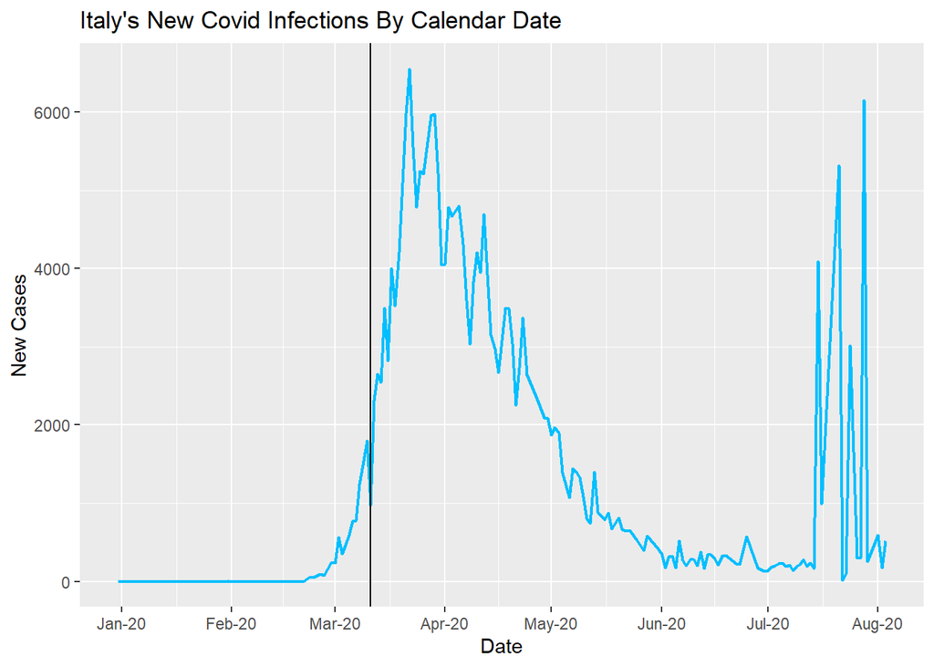

```r
#Plot a line graph using the clean covid data examining new cases over time
ggplot(data = filter(covid_data_clean, location == "Italy"), aes(x = date, y = new_cases, group = location, color = location))+
  geom_line(linewidth = 0.75, colour = "deepskyblue1")+
  #Scale x-axis by month
  scale_x_date(date_breaks = "1 month", date_labels = "%b-%y")+
  #Add title
  labs(title = "Italy's New Covid Infections By Calendar Date")+
  #Add vertical lines representing when lockdowns first began in each of the countries
  geom_vline(data = filter(covid_data_clean, location == "Italy"), aes(xintercept = covid_data_clean[588,11]))+
  #Add x-axis label
  xlab("Date")+
  #Add y-axis label
  ylab("New Cases")
```

In Italy, the first regional lockdowns targeted public spaces and social venues such as bars and pubs, prompting significant public frustration. As cases continued to rise, the government escalated its response by implementing a nationwide lockdown on March 21, closing all non‑essential industries, restricting movement, and shutting public parks and playgrounds. The graph shows a clear decline in daily case numbers following these measures, indicating that the restrictions had a substantial impact on transmission. Restrictions were gradually eased on May 18, with most businesses reopening and domestic travel permitted once again.

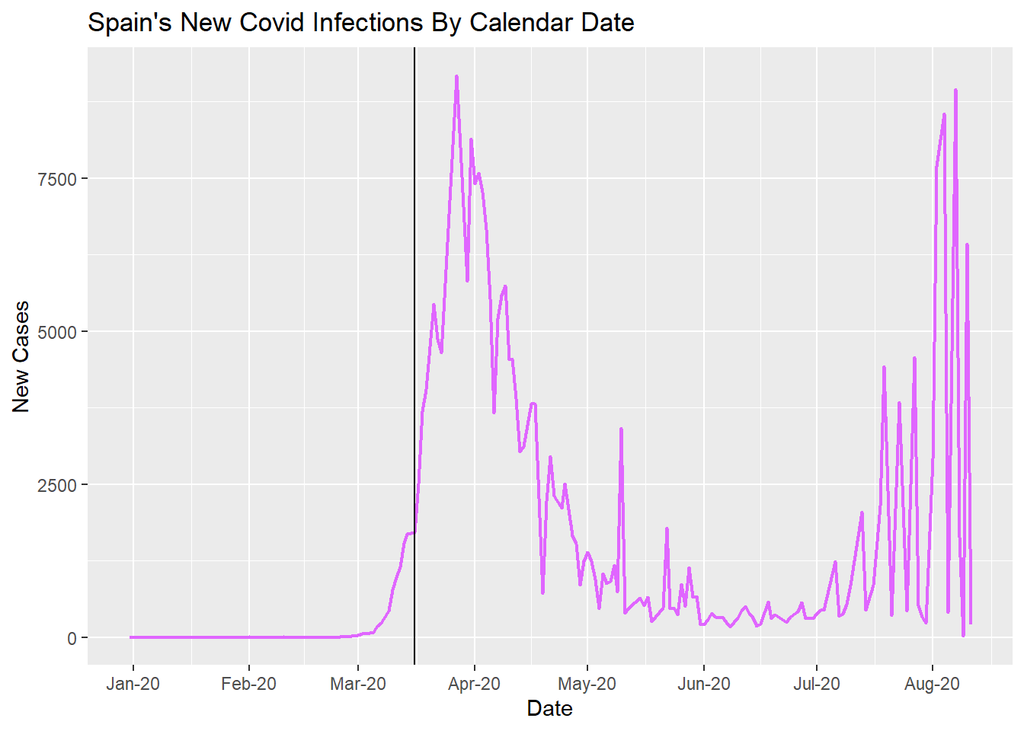

```r
#Plot a line graph using the clean covid data examining new cases over time
ggplot(data = filter(covid_data_clean, location == "Spain"), aes(x = date, y = new_cases, group = location, color = location))+
  geom_line(linewidth = 0.75, colour = "mediumorchid1")+
  #Scale x-axis by month
  scale_x_date(date_breaks = "1 month", date_labels = "%b-%y")+
  #Add title
  labs(title = "Spain's New Covid Infections By Calendar Date")+
  #Add vertical lines representing when lockdowns first began in each of the countries
  geom_vline(data = filter(covid_data_clean, location == "Spain"), aes(xintercept = covid_data_clean[213,11]))+
  #Add x-axis label
  xlab("Date")+
  #Add y-axis label
  ylab("New Cases")
```

In Spain, the first national lockdown was introduced on March 14, with restrictions tightened further on March 30 to limit movement for all non‑essential workers. When examining the graph, we see daily cases peaking around the time these stricter measures were implemented, followed by a sharp decline as the restrictions took effect. Lockdown measures were later eased on June 21, but cases began rising again in July, prompting several regions to reintroduce targeted restrictions. Having reviewed the daily case trends for each country, we can now explore whether a country’s economic status influences its COVID‑19 outcomes. To begin, we calculate the mean GDP per capita across all countries in the dataset.

```r
#Calculate mean GDP of locations
mean_gdp <- covid_data_clean %>%
  summarise(mean_gdp = mean(gdp_per_capita)) %>%
  pull(mean_gdp)
mean_gdp
```

```
## [1] 34592.54
```

Now we can create a new column that classifies each country based on how its GDP per capita compares to the global average. Countries with GDP values above the mean are labelled “Higher”, while those below the mean are labelled “Lower.” This grouping allows us to analyse infection and death rates across broad economic categories in a consistent and interpretable way.

```r
#Assigning new column to data frame which describes if the locations GDP per capita is higher or lower than the average called GDP_status
covid_data_clean <- covid_data_clean %>%
  mutate(
    GDP_status = ifelse(
      gdp_per_capita >= mean_gdp, #mean of GDP_per_capita
      "Higher",
      "Lower"
    )
  )
#Check data frame to see if new column has been added as intended
head(covid_data_clean)
```

```
##    location       date total_cases new_cases total_deaths new_deaths
## 1 Australia 2019-12-31           0         0            0          0
## 2 Australia 2020-01-01           0         0            0          0
## 3 Australia 2020-01-02           0         0            0          0
## 4 Australia 2020-01-03           0         0            0          0
## 5 Australia 2020-01-04           0         0            0          0
## 6 Australia 2020-01-05           0         0            0          0
##   gdp_per_capita population total_doses_administered
## 1       44648.71   25499881                 57988175
## 2       44648.71   25499881                 57988175
## 3       44648.71   25499881                 57988175
## 4       44648.71   25499881                 57988175
## 5       44648.71   25499881                 57988175
## 6       44648.71   25499881                 57988175
##   X..of.population.fully.vaccinated lockdown_date GDP_status
## 1                                86    2020-03-24     Higher
## 2                                86    2020-03-24     Higher
## 3                                86    2020-03-24     Higher
## 4                                86    2020-03-24     Higher
## 5                                86    2020-03-24     Higher
## 6                                86    2020-03-24     Higher
```

Now we can add two new variables to support our analysis. The first, daily infected case rate, is calculated as new_cases divided by each country’s population. The second, daily death rate, is computed as new_deaths divided by the population. These metrics standardise case and death counts across countries of different sizes, allowing for more meaningful comparisons.

```r
#Adding daily_infected_case_rate column
covid_data_clean <- covid_data_clean%>%
  mutate(
   daily_infected_case_rate = (new_cases / population)
  )

#Adding daily_death_rate column
covid_data_clean <- covid_data_clean%>%
  mutate(
   daily_death_rate = (new_deaths / population)
  )
head(covid_data_clean)
```

```
##    location       date total_cases new_cases total_deaths new_deaths
## 1 Australia 2019-12-31           0         0            0          0
## 2 Australia 2020-01-01           0         0            0          0
## 3 Australia 2020-01-02           0         0            0          0
## 4 Australia 2020-01-03           0         0            0          0
## 5 Australia 2020-01-04           0         0            0          0
## 6 Australia 2020-01-05           0         0            0          0
##   gdp_per_capita population total_doses_administered
## 1       44648.71   25499881                 57988175
## 2       44648.71   25499881                 57988175
## 3       44648.71   25499881                 57988175
## 4       44648.71   25499881                 57988175
## 5       44648.71   25499881                 57988175
## 6       44648.71   25499881                 57988175
##   X..of.population.fully.vaccinated lockdown_date GDP_status
## 1                                86    2020-03-24     Higher
## 2                                86    2020-03-24     Higher
## 3                                86    2020-03-24     Higher
## 4                                86    2020-03-24     Higher
## 5                                86    2020-03-24     Higher
## 6                                86    2020-03-24     Higher
##   daily_infected_case_rate daily_death_rate
## 1                        0                0
## 2                        0                0
## 3                        0                0
## 4                        0                0
## 5                        0                0
## 6                        0                0
```

Now that the data is prepared, we can visualise how infection rates differ across economic groups. The following plot illustrates the relationship between daily infected case rates and GDP status, allowing us to compare trends between higher‑ and lower‑GDP countries over time.

[output not shown]

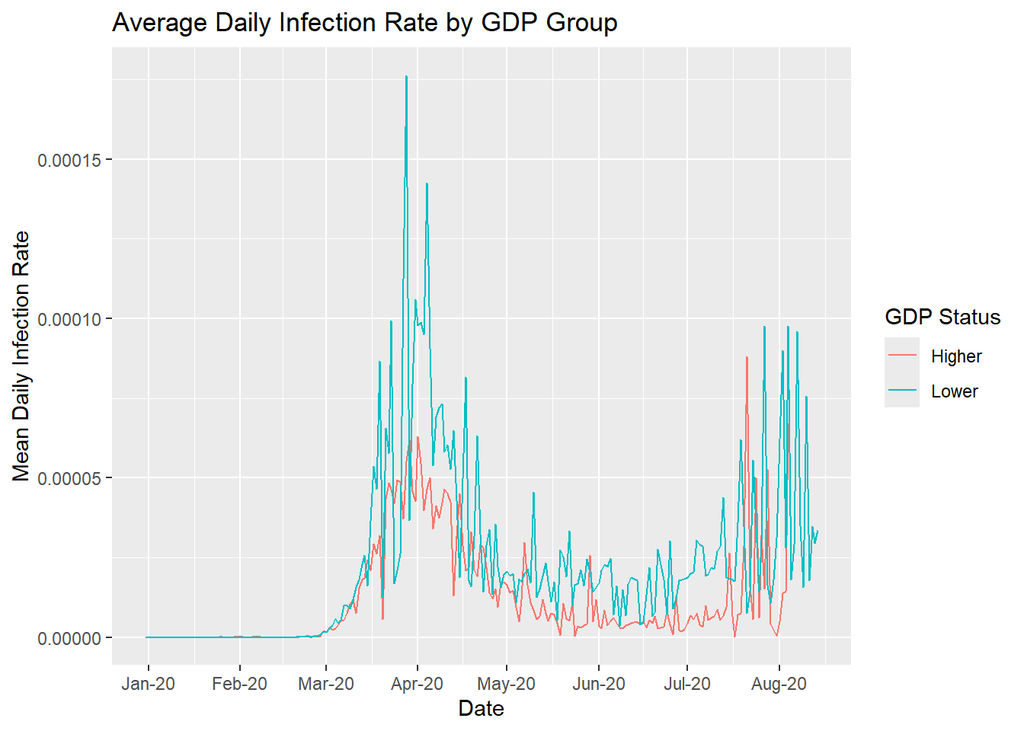

```r
#Generate plot of the relationship between the daily infected case rate within different GDP groups
covid_data_clean %>%
  #aggregate data
  group_by(date, GDP_status) %>%
  #Calculate mean_infected_rate value for y-axis
  summarise(mean_infected_rate = mean(daily_infected_case_rate, na.rm = TRUE)) %>%
  ggplot(aes(x = date, y = mean_infected_rate, color = GDP_status)) +
  geom_line(linewidth = 0.5) +
  scale_x_date(date_breaks = "1 month", date_labels = "%b-%y") +
  labs(title = "Average Daily Infection Rate by GDP Group",
       y = "Mean Daily Infection Rate",
       x = "Date",
       colour = "GDP Status")
```

As we can see from the graph, countries with lower GDP status tend to experience higher daily infected case rates. This suggests that economic capacity may play a role in shaping how effectively countries can limit transmission. To build on this, the next step is to examine whether the same pattern appears in mortality outcomes. Below, I plot the relationship between the daily death rate and GDP group to assess whether lower‑GDP countries also experience disproportionately higher fatality rates.

[output not shown]

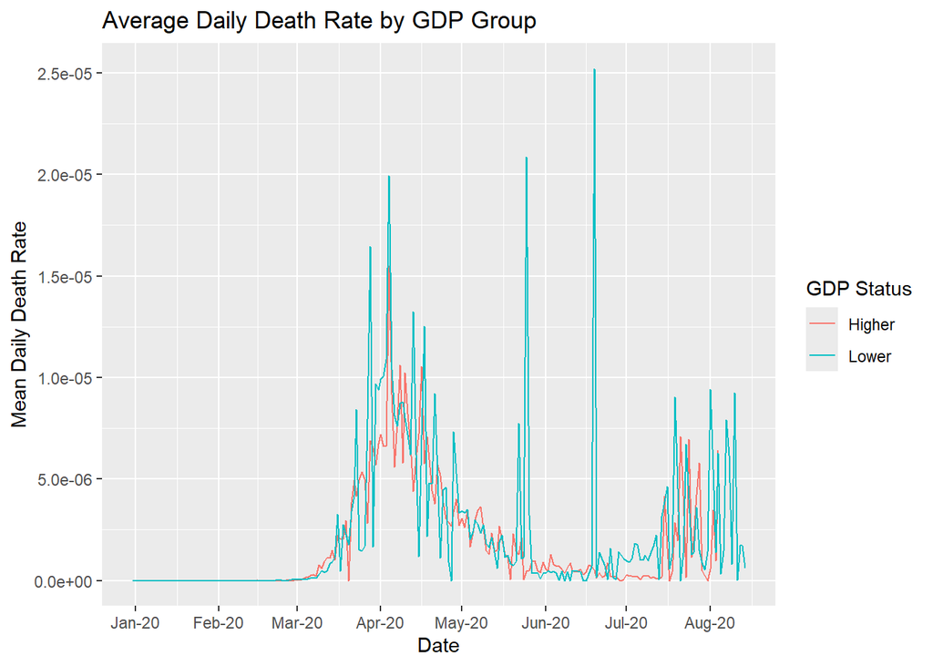

```r
#Generate plot of the relationship between the daily death rate within different GDP groups
covid_data_clean %>%
  #aggregate data
  group_by(date, GDP_status) %>%
  #Calculate mean_death_rate value for y-axis
  summarise(mean_death_rate = mean(daily_death_rate, na.rm = TRUE)) %>%
  ggplot(aes(x = date, y = mean_death_rate, color = GDP_status)) +
  geom_line(linewidth = 0.5) +
  scale_x_date(date_breaks = "1 month", date_labels = "%b-%y") +
  labs(title = "Average Daily Death Rate by GDP Group",
       y = "Mean Daily Death Rate",
       x = "Date",
       colour = "GDP Status")
```

## References

[1]Group of Eight (Australian universities) (April 2020). A Roadmap to Recovery – A Report for the Nation (PDF) (Report). [2]“Judicial Inquiry into Hotel Quarantine Program”. www.premier.vic.gov.au. Victorian Government. 2 July 2020. Retrieved 28 January 2021. [3] “France to extend coronavirus emergency for two months”. Al Jazeera. 2 May 2020. Archived from the original on 5 May 2020. Retrieved 4 May 2020. [4]“REPLAY. Coronavirus : prolongation du confinement jusqu’au 11 mai, tests, masques… Revivez l’allocution d’Emmanuel Macron”. France Info. 13 April 2020. Archived from the original on 14 April 2020. Retrieved 13 April 2020. [5]Arsalan Shahla (6 May 2020). “Iran’s Coronavirus Cases Creep Up After Officials Ease Lockdown”. Bloomberg. [6]“Coronavirus: Italy’s Conte offers hope as travel restrictions end”. BBC News. 3 June 2020. Retrieved 7 October 2020. [7]“Spain poised to tighten coronavirus lockdown after record daily toll”. MSN. Retrieved 2020-03-29. [8]“Coronavirus: Spain drives fears of European ‘second wave’”. BBC. 2020-07-25. [9] “Spain won’t declare another national state of alarm, allows regions to lockdown if necessary”. Euroactiv. 2020-08-26.